# Cyclistic Case Study

2024-06-26

# Data preparation

## Introduction

From this data, we are hoping to learn: 1) How do annual members and casual riders use Cyclistic bikes differently? 2) Why would casual riders buy Cyclistic annual memberships? 3) How can Cyclistic use digital media to influence casual riders to become members?

We can use R to create useful visualizations to help understand our data better and hopefully gain some insights about Cyclistic membership.

## Setting up

Let’s install packages and get some libraries up and running.

```r
#fundamentals
install.packages("tidyverse")
library(ggplot2)
library(dplyr)
library(tidyr)
library(readr)

#Geographic distances
install.packages("geosphere")
library(geosphere) #geo distance

#Date parsing
library(lubridate)

#Maps
install.packages(c("cowplot", "googleway",  "ggrepel",
"ggspatial", "libwgeom", "sf", "rnaturalearth", "rnaturalearthdata" ))

library("sf")
library("rnaturalearth")
library("rnaturalearthdata")

install.packages("devtools")
devtools::install_github("ropensci/rnaturalearthhires")
```

## Let’s get a sense of what’s going on with this data

Our dataset is split up into multiple files, so let’s read each one and combine them.

```r
df <- list.files(path="202306-divvy-tripdata", full.names = TRUE) %>%
  grep("\\.csv$", ., value = TRUE) %>%
  lapply(read_csv) %>%
  bind_rows
```

Let’s do a precursory cleanup …

```r
df <- df %>%
  drop_na()
```

…and see what we have.

```r
head(df, 100)
```

```
## # A tibble: 100 × 13
##    ride_id          rideable_type started_at          ended_at
##    <chr>            <chr>         <dttm>              <dttm>
##  1 DDEB93BC2CE9AA77 classic_bike  2023-05-10 16:47:01 2023-05-10 16:59:52
##  2 C07B70172FC92F59 classic_bike  2023-05-09 18:30:34 2023-05-09 18:39:28
##  3 2BA66385DF8F815A classic_bike  2023-05-30 15:01:21 2023-05-30 15:17:00
##  4 31EFCCB05F12D8EF docked_bike   2023-05-09 14:13:40 2023-05-09 14:47:20
##  5 71DFF834E1D3CE0B classic_bike  2023-05-06 16:47:22 2023-05-06 16:52:13
##  6 2117485899B4CEA4 classic_bike  2023-05-15 12:47:26 2023-05-15 13:00:05
##  7 811149F69AAE82DD electric_bike 2023-05-19 05:44:26 2023-05-19 05:47:24
##  8 D71F8A3BB45BDA05 classic_bike  2023-05-13 17:37:12 2023-05-13 17:43:27
##  9 B0E352E3CE2B6EE9 classic_bike  2023-05-05 06:28:09 2023-05-05 06:55:51
## 10 1348715B463F6610 classic_bike  2023-05-15 06:37:34 2023-05-15 07:01:51
## # ℹ 90 more rows
## # ℹ 9 more variables: start_station_name <chr>, start_station_id <chr>,
## #   end_station_name <chr>, end_station_id <chr>, start_lat <dbl>,
## #   start_lng <dbl>, end_lat <dbl>, end_lng <dbl>, member_casual <chr>
```

### Utility Columns

Some of our data is going to be easier to work with if we pre-compute some expressions. Let’s calculate the duration of each bike ride.

```r
#time of ride
df$duration_secs <- as.numeric(difftime(df$ended_at, df$started_at), units = "secs")
```

We can also calculate the distance between the start point and end point. To estimate the actual distance travelled by the rider, we can get the distance “as the crow flies”, as well as the so-called [Manhattan distance](https://en.wikipedia.org/wiki/Taxicab_geometry).

```r
great_circle_distances <- numeric(nrow(df))
manhattan_distances <- numeric(nrow(df))

# Calculate distances in chunks
chunk_size <- 20000  # Adjust the chunk size based on system memory capacity
for (i in seq(1, nrow(df), by = chunk_size)) {
  chunk_indices <- i:min(i + chunk_size - 1, nrow(df))
  start_lng_lat <- cbind(df$start_lng[chunk_indices], df$start_lat[chunk_indices])
  end_lng_lat <- cbind(df$end_lng[chunk_indices], df$end_lat[chunk_indices])

  manhattan_offset_point <- cbind(df$start_lng[chunk_indices], df$end_lat[chunk_indices])

  # Calculate distances for the current chunk
  great_circle_distances[chunk_indices] <- distGeo(start_lng_lat, end_lng_lat)
  manhattan_distances[chunk_indices] <-  distGeo(start_lng_lat, manhattan_offset_point) + distGeo(manhattan_offset_point, end_lng_lat)

  #Show progress
  #message <-round(100*i/nrow(df),1)
  #cat(paste(message," "))

}

# Assign distances back to the dataframe
df$great_circle_dist_m <- great_circle_distances
df$manhattan_dist_m <- manhattan_distances
```

We can also parse the dates and split their individual components into separate columns

```r
df$start_year <- year(df$started_at)
df$start_month <- month(df$started_at)
df$start_day <- day(df$started_at)
df$start_hour <- hour(df$started_at)
df$start_day_of_week <- wday(df$started_at, label = TRUE)
df$start_day_is_weekend <- df$start_day_of_week %in% c("Sat", "Sun")


df$end_year <- year(df$ended_at)
df$end_month <- month(df$ended_at)
df$end_day <- day(df$ended_at)
df$end_hour <- hour(df$ended_at)
df$end_day_of_week <- wday(df$ended_at, label = TRUE)
df$end_day_is_weekend <- df$end_day_of_week %in% c("Sat", "Sun")
```

### A strange anomaly

Some rows have the odd characteristic of ending before they start!

```r
#check rides that are shorter than 1 second
time_warp_rides <- df %>%
  filter(duration_secs < 1)

time_warp_rides %>%
  arrange(duration_secs) %>%
  head(100)
```

```
## # A tibble: 100 × 28
##    ride_id          rideable_type started_at          ended_at
##    <chr>            <chr>         <dttm>              <dttm>
##  1 5C5FCC49C148635F classic_bike  2023-11-05 01:55:47 2023-11-05 01:01:13
##  2 274EDE47C11F43AF classic_bike  2023-11-05 01:55:51 2023-11-05 01:02:37
##  3 0AF3917F317F4C5F classic_bike  2023-11-05 01:54:43 2023-11-05 01:01:31
##  4 D17C0701A2AC27A8 classic_bike  2023-11-05 01:53:49 2023-11-05 01:00:41
##  5 FBDEF92A65F125D9 classic_bike  2023-11-05 01:58:37 2023-11-05 01:05:42
##  6 C182738D5AF4775B classic_bike  2023-11-05 01:54:15 2023-11-05 01:01:33
##  7 822A055416791A8D classic_bike  2023-11-05 01:55:07 2023-11-05 01:02:40
##  8 A2B29BF080FD1672 classic_bike  2023-11-05 01:55:41 2023-11-05 01:03:22
##  9 368C90D097E27F50 classic_bike  2023-11-05 01:54:53 2023-11-05 01:02:56
## 10 3FE1CB266FEFC4F8 classic_bike  2023-11-05 01:56:53 2023-11-05 01:06:00
## # ℹ 90 more rows
## # ℹ 24 more variables: start_station_name <chr>, start_station_id <chr>,
## #   end_station_name <chr>, end_station_id <chr>, start_lat <dbl>,
## #   start_lng <dbl>, end_lat <dbl>, end_lng <dbl>, member_casual <chr>,
## #   duration_secs <dbl>, great_circle_dist_m <dbl>, manhattan_dist_m <dbl>,
## #   start_year <dbl>, start_month <dbl>, start_day <int>, start_hour <int>,
## #   start_day_of_week <ord>, start_day_is_weekend <lgl>, end_year <dbl>, …
```

```r
#grab rides which are all on the same day
dst_rides <- time_warp_rides %>%
  filter(end_month == 11 &
           end_day == 5 & end_year == 2023 & duration_secs < -100)

head(dst_rides, 100)
```

```
## # A tibble: 30 × 28
##    ride_id          rideable_type started_at          ended_at
##    <chr>            <chr>         <dttm>              <dttm>
##  1 9D73776DE22E7CC3 classic_bike  2023-11-05 01:51:21 2023-11-05 01:01:21
##  2 B94077F69CC627E5 electric_bike 2023-11-05 01:44:22 2023-11-05 01:01:58
##  3 61E5500E59B492F2 electric_bike 2023-11-05 01:56:06 2023-11-05 01:17:33
##  4 D0AA61C39C6A4403 classic_bike  2023-11-05 01:51:59 2023-11-05 01:02:34
##  5 4B09F814AA33731D classic_bike  2023-11-05 01:58:10 2023-11-05 01:13:55
##  6 6F9C6ECAB4E405CD electric_bike 2023-11-05 01:48:55 2023-11-05 01:04:35
##  7 FBDEF92A65F125D9 classic_bike  2023-11-05 01:58:37 2023-11-05 01:05:42
##  8 05673545F40646D6 classic_bike  2023-11-05 01:55:40 2023-11-05 01:09:56
##  9 B9C22958E273FFE6 classic_bike  2023-11-05 01:50:34 2023-11-05 01:06:31
## 10 CDE6EADF5CA8D2FD classic_bike  2023-11-05 01:49:04 2023-11-05 01:06:38
## # ℹ 20 more rows
## # ℹ 24 more variables: start_station_name <chr>, start_station_id <chr>,
## #   end_station_name <chr>, end_station_id <chr>, start_lat <dbl>,
## #   start_lng <dbl>, end_lat <dbl>, end_lng <dbl>, member_casual <chr>,
## #   duration_secs <dbl>, great_circle_dist_m <dbl>, manhattan_dist_m <dbl>,
## #   start_year <dbl>, start_month <dbl>, start_day <int>, start_hour <int>,
## #   start_day_of_week <ord>, start_day_is_weekend <lgl>, end_year <dbl>, …
```

While many of these are surely errors or equipment malfunctions, a large number of these errors occur in the very early morning on November 5th, 2023. This date and the 2am hour perfectly coincide with the United States Daylight Savings switch. These rows can be offset accordingly, and the data can be reclaimed!

```r
# update the DST-affected ride's durations
# add 1 hour

indices_to_mutate <- df$ride_id %in% dst_rides$ride_id
df$duration_secs[indices_to_mutate] <- df$duration_secs[indices_to_mutate] + (60 * 60)
```

Now that we have some better information about each ride, some erroneous rides can be filtered out.

```r
dataframe <- filter(df, duration_secs>0 & great_circle_dist_m>0 & manhattan_dist_m>0 )
```

### Let’s see what we got!

Alright, our data is in much better shape.

```r
colnames(dataframe)
```

```
##  [1] "ride_id"              "rideable_type"        "started_at"
##  [4] "ended_at"             "start_station_name"   "start_station_id"
##  [7] "end_station_name"     "end_station_id"       "start_lat"
## [10] "start_lng"            "end_lat"              "end_lng"
## [13] "member_casual"        "duration_secs"        "great_circle_dist_m"
## [16] "manhattan_dist_m"     "start_year"           "start_month"
## [19] "start_day"            "start_hour"           "start_day_of_week"
## [22] "start_day_is_weekend" "end_year"             "end_month"
## [25] "end_day"              "end_hour"             "end_day_of_week"
## [28] "end_day_is_weekend"
```

```r
head(dataframe,100)
```

```
## # A tibble: 100 × 28
##    ride_id          rideable_type started_at          ended_at
##    <chr>            <chr>         <dttm>              <dttm>
##  1 DDEB93BC2CE9AA77 classic_bike  2023-05-10 16:47:01 2023-05-10 16:59:52
##  2 C07B70172FC92F59 classic_bike  2023-05-09 18:30:34 2023-05-09 18:39:28
##  3 2BA66385DF8F815A classic_bike  2023-05-30 15:01:21 2023-05-30 15:17:00
##  4 31EFCCB05F12D8EF docked_bike   2023-05-09 14:13:40 2023-05-09 14:47:20
##  5 71DFF834E1D3CE0B classic_bike  2023-05-06 16:47:22 2023-05-06 16:52:13
##  6 2117485899B4CEA4 classic_bike  2023-05-15 12:47:26 2023-05-15 13:00:05
##  7 811149F69AAE82DD electric_bike 2023-05-19 05:44:26 2023-05-19 05:47:24
##  8 D71F8A3BB45BDA05 classic_bike  2023-05-13 17:37:12 2023-05-13 17:43:27
##  9 B0E352E3CE2B6EE9 classic_bike  2023-05-05 06:28:09 2023-05-05 06:55:51
## 10 1348715B463F6610 classic_bike  2023-05-15 06:37:34 2023-05-15 07:01:51
## # ℹ 90 more rows
## # ℹ 24 more variables: start_station_name <chr>, start_station_id <chr>,
## #   end_station_name <chr>, end_station_id <chr>, start_lat <dbl>,
## #   start_lng <dbl>, end_lat <dbl>, end_lng <dbl>, member_casual <chr>,
## #   duration_secs <dbl>, great_circle_dist_m <dbl>, manhattan_dist_m <dbl>,
## #   start_year <dbl>, start_month <dbl>, start_day <int>, start_hour <int>,
## #   start_day_of_week <ord>, start_day_is_weekend <lgl>, end_year <dbl>, …
```

# Analysis and Visualization

### What type of bikes do casual riders and members use?

There are three bikes in use: classic, docked, and electric. Let’s see if there’s a noticeable difference in the way casual riders and members choose bike styles.

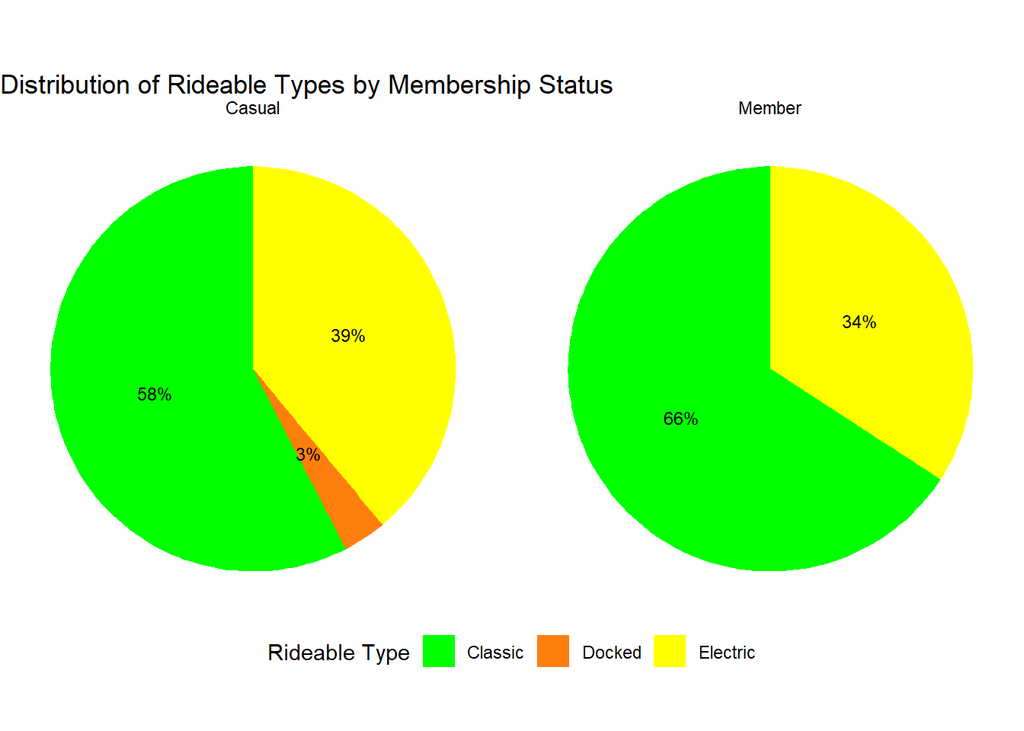

```r
#Create Labels
rideable_type_labels <- c(
  "classic_bike" = "Classic",
  "docked_bike" = "Docked",
  "electric_bike" = "Electric"
)
member_casual_labels <- c("member" = "Member", "casual" = "Casual")

#Aggregate and count data
df_agg <- dataframe %>%
  group_by(member_casual, rideable_type) %>%
  summarise(count = n(), .groups = 'drop') %>%
  group_by(member_casual) %>%
  mutate(percentage = count / sum(count) * 100) #Calculate percentage of share

# Create the pie charts with facet_wrap
df_agg %>%
  ggplot(aes(x = "", y = count, fill = rideable_type)) +
  geom_bar(stat = "identity",
           width = 1,
           position = "fill") +
  coord_polar(theta = "y") +
  facet_wrap( ~ member_casual, labeller = as_labeller(member_casual_labels)) +
  theme_void() +
  geom_text(aes(label = paste0(round(percentage, 0), "%")),
            position = position_fill(vjust = 0.5),
            size = 3) +
  scale_fill_manual(
    values = c(
      "classic_bike" = "green",
      "docked_bike" = "#ff7f0e",
      "electric_bike" = "yellow"
    ),
    labels = rideable_type_labels
  ) +
  theme(legend.position = "bottom") +
  labs(fill = "Rideable Type",
       title = "Distribution of Rideable Types by Membership Status",
       x = NULL,
       y = NULL)
```

Not really!

### How long does each group ride the bikes?

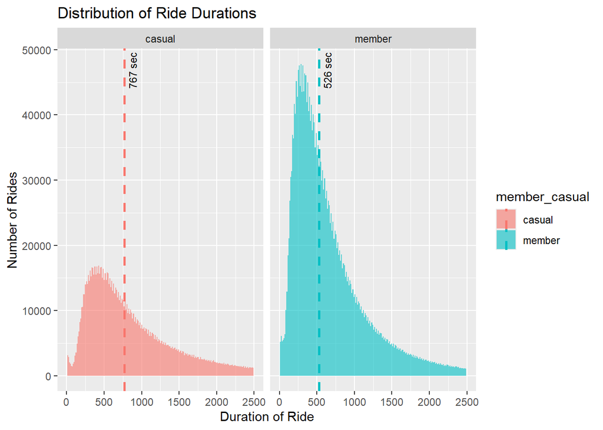

```r
#calculate the medians
medians <- dataframe %>%
  group_by(member_casual) %>%
  summarize(median = median(duration_secs))

#plot
ggplot(data = dataframe, aes(x = duration_secs, fill = member_casual)) +
   geom_vline(data = medians, aes(xintercept = median, color = member_casual),
             linetype = "dashed", linewidth = 1) +
   geom_text(data = medians, aes(x = median, y = Inf, label =paste(round(median, 2),"sec" )             ),
            angle = 90, vjust = 1.5, hjust = 1.1, size = 3, color = "black") +
  geom_histogram(bins = 200, alpha = 0.6) +
  xlim(0, 2500) +
  facet_wrap( ~ member_casual)+
  labs(
       title = "Distribution of Ride Durations",
       x = "Duration of Ride",
       y = "Number of Rides")
```

### How far does each group ride the bikes?

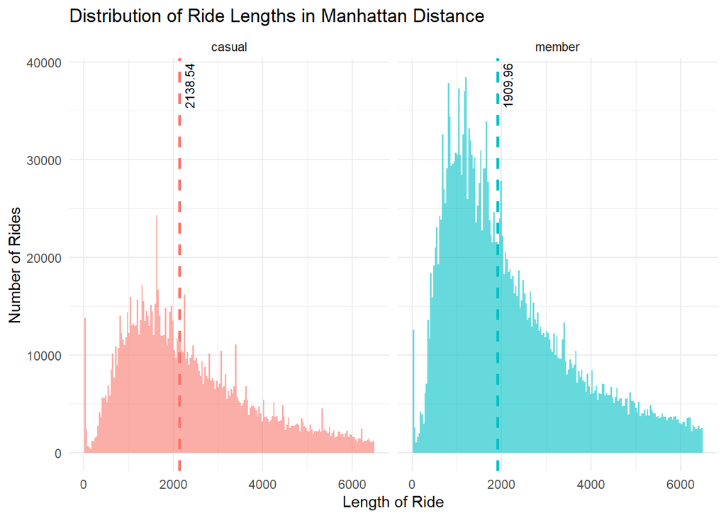

```r
# Calculate the medians
medians <- dataframe %>%
  group_by(member_casual) %>%
  summarize(median = median(manhattan_dist_m))

# plot 1
ggplot(data = dataframe, aes(x = manhattan_dist_m, fill = member_casual)) +
  geom_histogram(bins = 200, alpha = 0.6, position = "identity") +
  xlim(0, 6500) +
  facet_wrap(~ member_casual) +
  geom_vline(data = medians, aes(xintercept = median, color = member_casual),
             linetype = "dashed", linewidth = 1) +
  geom_text(data = medians, aes(x = median, y = Inf, label = round(median, 2)),
            angle = 90, vjust = 1.5, hjust = 1.1, size = 3, color = "black") +
  theme_minimal() +
  theme(legend.position = "none")+
  labs(
       title = "Distribution of Ride Lengths in Manhattan Distance",
       x = "Length of Ride",
       y = "Number of Rides")
```

```r
medians <- dataframe %>%
  group_by(member_casual) %>%
  summarize(median = median(great_circle_dist_m))
```

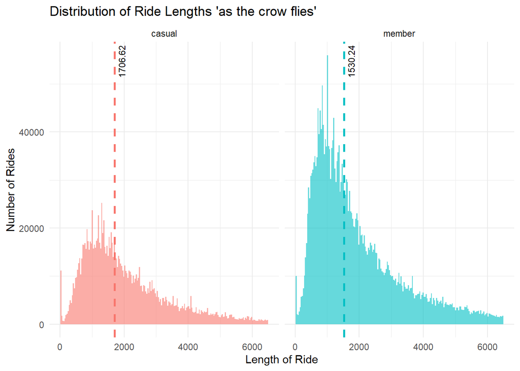

Both groups ride their bikes for similar distances; the medians are in the 1500-1700m range, and both groups peak ~1250m.

### What time of year does each group ride the bikes?

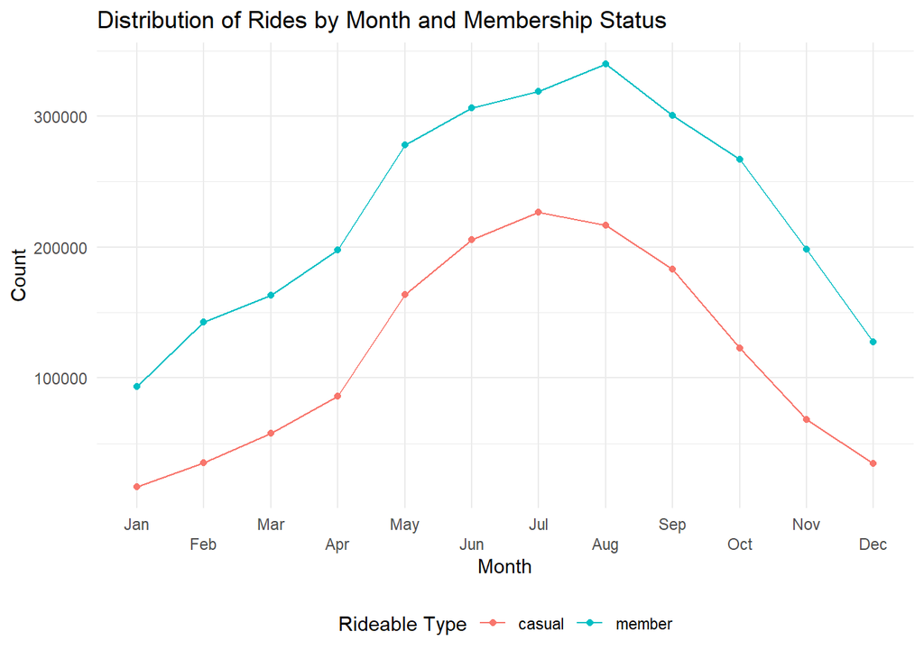

```r
#Aggregate and count data
df_agg <- dataframe %>%
  group_by(member_casual, start_month) %>%
  summarise(count = n(), .groups = 'drop')

df_agg %>%
  ggplot(aes(
    x = factor(
      start_month,
      levels = 1:length(month.abb),
      labels = month.abb
    ),
    y = count,
    color = member_casual,
    group = member_casual
  )) +
  geom_line() +
  geom_point() +
  scale_x_discrete(guide = guide_axis(n.dodge = 2)) +  # Adjust the spacing of x-axis labels
  theme_minimal() +
  theme(legend.position = "bottom") +
  labs(
    color = "Rideable Type",
    title = "Distribution of Rides by Month and Membership Status",
    x = "Month",
    y = "Count"
  )
```

The shape of each curve is very similar, both members and casual riders prefer to ride in the summer months. Safety concerns due to weather such as ice and snow –not to mention the cold weather– may explain the low numbers in wintertime.

### What day of the week does each group ride the bikes?

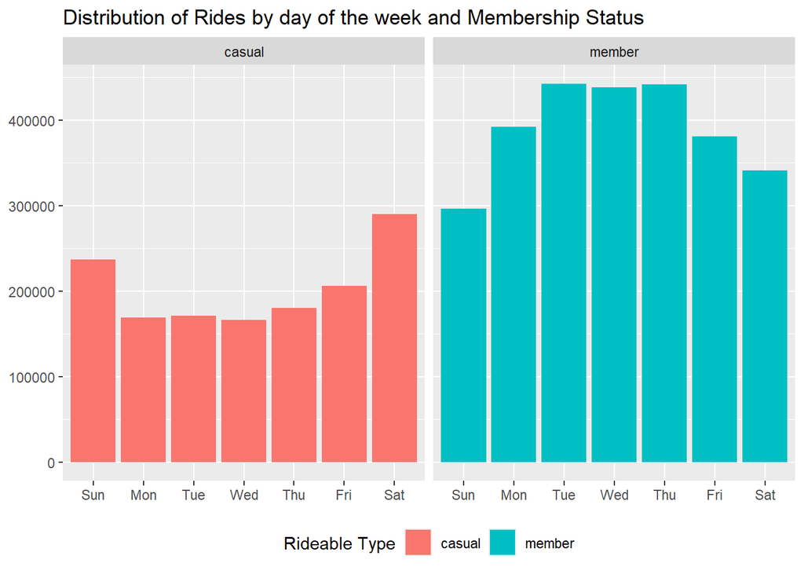

```r
#Aggregate and count data
df_agg <- dataframe %>%
  group_by(member_casual, start_day_of_week) %>%
  summarise(count = n(), .groups = 'drop')

# Create the  charts with facet_wrap
df_agg %>%
  ggplot(aes(x = start_day_of_week, y = count, fill = member_casual)) +

  geom_bar(stat = "identity", width = .9) +

  theme(legend.position = "bottom") +
  facet_wrap( ~ member_casual) +
  labs(fill = "Rideable Type",
       title = "Distribution of Rides by day of the week and Membership Status",
       x = NULL,
       y = NULL)
```

Clearly the preference for members is to use the bikes Monday-Friday, and to use them less during the weekend. For casual riders, the opposite is true.

### What time of day does each group ride the bikes?

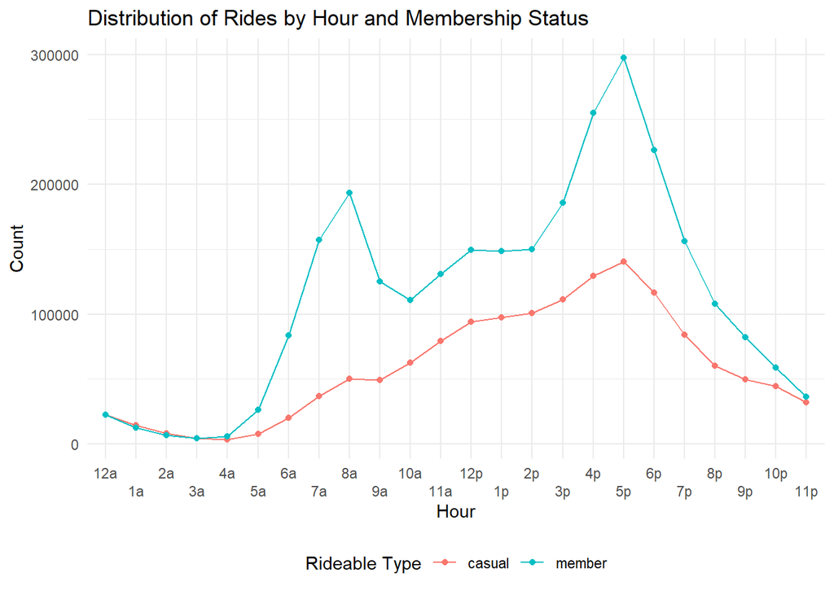

```r
#Create Labels
hour_labels <- c(  "0" = "12a",  "1" = "1a",  "2" = "2a",  "3" = "3a",  "4" = "4a",  "5" = "5a",  "6" = "6a",  "7" = "7a",  "8" = "8a",  "9" = "9a",  "10" = "10a",  "11" = "11a",  "12" = "12p",  "13" = "1p",  "14" = "2p",  "15" = "3p",  "16" = "4p",  "17" = "5p",  "18" = "6p",  "19" = "7p",  "20" = "8p",  "21" = "9p",  "22" = "10p",  "23" = "11p")


#Aggregate and count data
df_agg <- dataframe %>%
  group_by(member_casual, start_hour) %>%
  summarise(count = n(), .groups = 'drop')

# plot
df_agg %>%
  ggplot(aes(
    x = factor(start_hour, levels = 0:23, labels = hour_labels),
    y = count,
    color = member_casual,
    group = member_casual
  )) +
  geom_line() +
  scale_x_discrete(guide = guide_axis(n.dodge = 2)) +  # Adjust the spacing of x-axis labels

  geom_point() +
  theme_minimal() +
  theme(legend.position = "bottom") +
  labs(
    color = "Rideable Type",
    title = "Distribution of Rides by Hour and Membership Status",
    x = "Hour",
    y = "Count"
  )
```

This graph shows the single most meaningful difference in membervs. usage. The members ride their bikes on their commutes! The huge peaks in the rush-hour times call to mind the classic 9-to-5 workday. To help confirm this theory, we can dive deeper into the workweek, and filter out Saturday and Sunday.

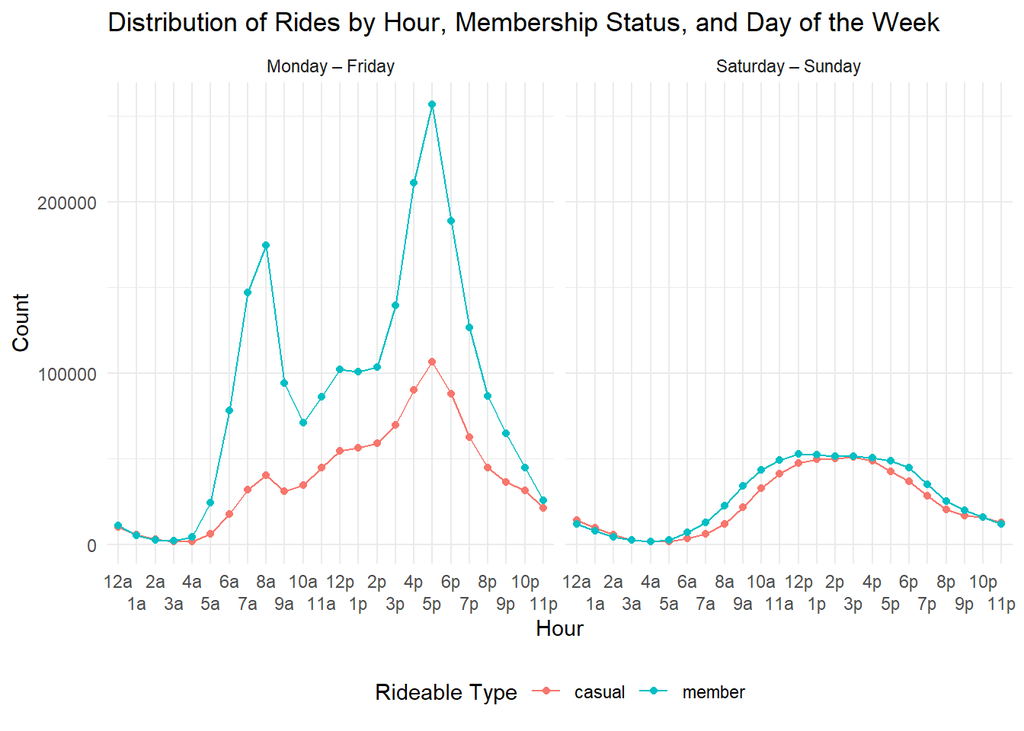

```r
#Aggregate and count
df_agg <- df %>%
  group_by(member_casual, start_hour, start_day_is_weekend) %>%
  summarise(count = n(), .groups = 'drop')

#plot
df_agg %>%
  ggplot(aes(
    x = factor(start_hour, levels = 0:23, labels = hour_labels),
    y = count,
    color = member_casual,
    group = member_casual
  )) +
  geom_line() +
  scale_x_discrete(guide = guide_axis(n.dodge = 2)) +  # Adjust the spacing of x-axis labels
  facet_wrap( ~ start_day_is_weekend , labeller = as_labeller(c("FALSE"="Monday – Friday", "TRUE"= "Saturday – Sunday")))+
  geom_point() +
  theme_minimal() +
  theme(legend.position = "bottom") +
  labs(
    color = "Rideable Type",
    title = "Distribution of Rides by Hour, Membership Status, and Day of the Week",
    x = "Hour",
    y = "Count"
  )
```

Now we can clearly see: there is hardly a perceptible difference between casuals and members during the daylight hours on the weekend. The rush-hour period is a huge area of interest.

## Prepping data for coordinate mapping

```r
# Get relevant cols, and remove cols without precise coordinates
filtered_df <- df[, c(
  "start_station_id",
  "member_casual",
  "end_station_id",
  "start_lat",
  "start_lng",
  "end_lat",
  "end_lng"
)]


# Combine start and end "interactions" into one table
interactions_starts <- filtered_df[, c("member_casual", "start_station_id", "start_lat", "start_lng")]
names(interactions_starts) <- c("member_casual", "station_id", "lat", "lng")

interactions_ends <- filtered_df[, c("member_casual", "start_station_id", "start_lat", "start_lng")]
names(interactions_ends) <- c("member_casual", "station_id", "lat", "lng")

station_interactions_raw <- bind_rows(interactions_starts, interactions_ends)


#Count interactions
station_interactions_temp <- station_interactions_raw %>%
  group_by(station_id, member_casual) %>%
  mutate(station_count = n())


station_interactions_temp <- station_interactions_temp %>%
  mutate(unique_id = paste(member_casual, sep = "_", station_id))

#All rows for same station are now identical
station_interactions <- station_interactions_temp %>%
  distinct(unique_id, station_id, .keep_all = TRUE) %>%
  filter(!is.na(station_id))
```

# Geographic Analysis

### Do members and casual riders use bike stations in different neighborhoods?

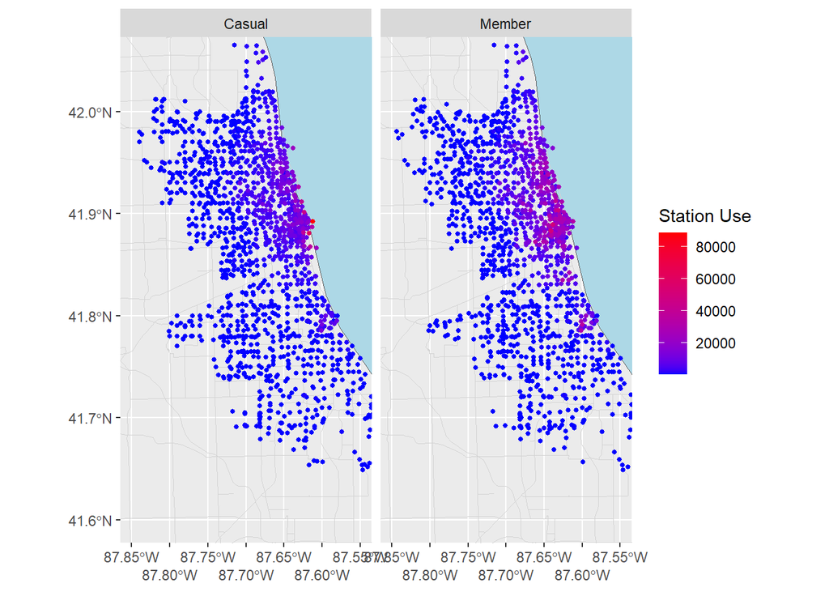

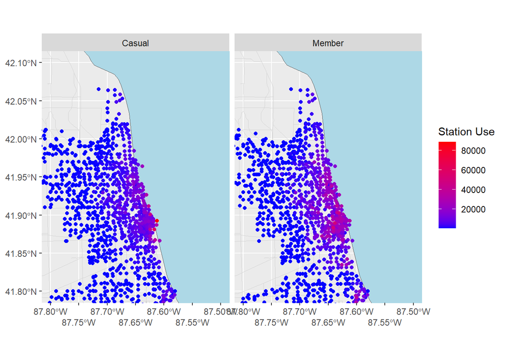

```r
lakes_data <- ne_download(
  scale = 10,
  type = "lakes_north_america",
  category = "physical",
  destdir = "maps/",
  load = FALSE
)
roads_data <- ne_download(
  scale = 10,
  type = "roads_north_america",
  category = "cultural",
  destdir = "maps/",
  load = FALSE
)

lakes <- ne_load(
  scale = 10,
  type = "lakes",
  destdir = "maps",
  returnclass = "sf"
)
roads <- ne_load(
  scale = 10,
  type = "roads_north_america",
  destdir = "maps",
  returnclass = "sf"
)  %>%
  filter(state == "Illinois")


coordinates_sf <- station_interactions %>% arrange(station_count) %>% st_as_sf(., coords = c("lng", "lat"), crs = 4326)


value_range <- range(station_interactions$station_count, na.rm = TRUE)
breaks <- seq(value_range[1], value_range[2], length.out = 10)


#plot 1
ggplot() +
  geom_sf(data = lakes, fill = "lightblue") +
  geom_sf(data = roads,
          colour = "lightgray",
          linewidth = 0.2) +

  facet_wrap(~ member_casual, labeller = as_labeller(member_casual_labels)) +
  geom_sf(data = coordinates_sf, aes(color = station_count), size = 1) +  # Color points based on station_count
  scale_colour_gradient(
    name = 'Station Use' ,
    n.breaks = 5,
    low = "blue",
    high = "red"
  ) +  # Custom color scale
  coord_sf(xlim = c(-87.85, -87.55), ylim = c(41.6, 42.05))  +
  scale_x_continuous(guide = guide_axis(n.dodge = 2))
```

Seems like members and casuals have very similar usage maps.

# Next Steps

## Key takeaways

- Members use their bikes during the workweek, Monday – Friday
- Members use their bikes substantially more during rush-hour times: ~8am and ~5pm
  - Members are likely using their bikes to commute
- All riders use their bikes more during the summer months
- Certain neighborhoods get more usage and are “hotspots”

## Recommendations and Audience Targets

### Target casual users who commute

Professionals or students who commute on trains and other public transportation may be interested in more direct alternatives. Students in summer programs may be more receptive to a bike than students during the school year in the fall, winter, and spring.

### Offer seasonal or summer memberships

It’s only natural that bike rides are down in the months which are more likely to have wintry conditions. Offering less-than-annual memberships, especially during the summer months, may help persuade those riders who are not willing to commit to riding a bike in Chicago year-round.

### Heat up the cold spots

The hotspot neighborhoods are doing great! But some of the “colder” areas surrounding those hotspots may benefit from additional advertising and promotion.